# Risk Factor Analysis

## Outcome Variable

**Outcome Variable:** y_rate_haz

## Predictor Variables

**Intervention Variable:** trth2o

**Adjustment Set:**

- arm
- sex
- W_mage
- meducyrs
- feducyrs
- hfoodsec
- W_mhtcm
- W_mwtkg
- W_mbmi
- W_nrooms
- W_nhh
- W_nchldlt5
- cleanck
- impfloor
- impsan
- safeh20
- delta_meducyrs
- delta_feducyrs
- delta_hfoodsec
- delta_W_mhtcm
- delta_W_mwtkg
- delta_W_mbmi
- delta_W_nrooms
- delta_W_nhh
- delta_W_nchldlt5
- delta_cleanck
- delta_impfloor
- delta_impsan
- delta_safeh20

## Stratifying Variables

The analysis was stratified on these variable(s):

- agecat
- studyid
- country

## Data Summary

| agecat | studyid | country | trth2o | n_cell | n |
| --- | --- | --- | --- | --- | --- |
| 0-3 months | ki0047075b-MAL-ED | BANGLADESH | 0 | 2 | 134 |
| 0-3 months | ki0047075b-MAL-ED | BANGLADESH | 1 | 132 | 134 |
| 0-3 months | ki0047075b-MAL-ED | BRAZIL | 0 | 72 | 84 |
| 0-3 months | ki0047075b-MAL-ED | BRAZIL | 1 | 12 | 84 |
| 0-3 months | ki0047075b-MAL-ED | INDIA | 0 | 4 | 6 |
| 0-3 months | ki0047075b-MAL-ED | INDIA | 1 | 2 | 6 |
| 0-3 months | ki0047075b-MAL-ED | NEPAL | 0 | 12 | 63 |
| 0-3 months | ki0047075b-MAL-ED | NEPAL | 1 | 51 | 63 |
| 0-3 months | ki0047075b-MAL-ED | PERU | 0 | 9 | 46 |
| 0-3 months | ki0047075b-MAL-ED | PERU | 1 | 37 | 46 |
| 0-3 months | ki0047075b-MAL-ED | SOUTH AFRICA | 0 | 9 | 10 |
| 0-3 months | ki0047075b-MAL-ED | SOUTH AFRICA | 1 | 1 | 10 |
| 0-3 months | ki0047075b-MAL-ED | TANZANIA, UNITED REPUBLIC OF | 0 | 32 | 38 |
| 0-3 months | ki0047075b-MAL-ED | TANZANIA, UNITED REPUBLIC OF | 1 | 6 | 38 |
| 0-3 months | ki1000108-CMC-V-BCS-2002 | INDIA | 0 | 0 | 25 |
| 0-3 months | ki1000108-CMC-V-BCS-2002 | INDIA | 1 | 25 | 25 |
| 0-3 months | ki1000108-IRC | INDIA | 0 | 0 | 118 |
| 0-3 months | ki1000108-IRC | INDIA | 1 | 118 | 118 |
| 0-3 months | ki1017093b-PROVIDE | BANGLADESH | 0 | 620 | 634 |
| 0-3 months | ki1017093b-PROVIDE | BANGLADESH | 1 | 14 | 634 |
| 0-3 months | ki1017093c-NIH-Crypto | BANGLADESH | 0 | 319 | 720 |
| 0-3 months | ki1017093c-NIH-Crypto | BANGLADESH | 1 | 401 | 720 |
| 3-6 months | ki0047075b-MAL-ED | BANGLADESH | 0 | 2 | 132 |
| 3-6 months | ki0047075b-MAL-ED | BANGLADESH | 1 | 130 | 132 |
| 3-6 months | ki0047075b-MAL-ED | BRAZIL | 0 | 90 | 103 |
| 3-6 months | ki0047075b-MAL-ED | BRAZIL | 1 | 13 | 103 |
| 3-6 months | ki0047075b-MAL-ED | INDIA | 0 | 4 | 7 |
| 3-6 months | ki0047075b-MAL-ED | INDIA | 1 | 3 | 7 |
| 3-6 months | ki0047075b-MAL-ED | NEPAL | 0 | 14 | 82 |
| 3-6 months | ki0047075b-MAL-ED | NEPAL | 1 | 68 | 82 |

[output cut: 64 more lines]

The following strata were considered:

- agecat: 0-3 months, studyid: ki0047075b-MAL-ED, country: BANGLADESH
- agecat: 0-3 months, studyid: ki0047075b-MAL-ED, country: BRAZIL
- agecat: 0-3 months, studyid: ki0047075b-MAL-ED, country: INDIA
- agecat: 0-3 months, studyid: ki0047075b-MAL-ED, country: NEPAL
- agecat: 0-3 months, studyid: ki0047075b-MAL-ED, country: PERU
- agecat: 0-3 months, studyid: ki0047075b-MAL-ED, country: SOUTH AFRICA
- agecat: 0-3 months, studyid: ki0047075b-MAL-ED, country: TANZANIA, UNITED REPUBLIC OF
- agecat: 0-3 months, studyid: ki1000108-CMC-V-BCS-2002, country: INDIA
- agecat: 0-3 months, studyid: ki1000108-IRC, country: INDIA
- agecat: 0-3 months, studyid: ki1017093b-PROVIDE, country: BANGLADESH
- agecat: 0-3 months, studyid: ki1017093c-NIH-Crypto, country: BANGLADESH
- agecat: 12-24 months, studyid: ki0047075b-MAL-ED, country: BANGLADESH
- agecat: 12-24 months, studyid: ki0047075b-MAL-ED, country: BRAZIL
- agecat: 12-24 months, studyid: ki0047075b-MAL-ED, country: INDIA
- agecat: 12-24 months, studyid: ki0047075b-MAL-ED, country: NEPAL
- agecat: 12-24 months, studyid: ki0047075b-MAL-ED, country: PERU
- agecat: 12-24 months, studyid: ki0047075b-MAL-ED, country: SOUTH AFRICA
- agecat: 12-24 months, studyid: ki0047075b-MAL-ED, country: TANZANIA, UNITED REPUBLIC OF
- agecat: 12-24 months, studyid: ki1000108-CMC-V-BCS-2002, country: INDIA
- agecat: 12-24 months, studyid: ki1000108-IRC, country: INDIA
- agecat: 12-24 months, studyid: ki1017093b-PROVIDE, country: BANGLADESH
- agecat: 12-24 months, studyid: ki1017093c-NIH-Crypto, country: BANGLADESH
- agecat: 12-24 months, studyid: ki1113344-GMS-Nepal, country: NEPAL
- agecat: 3-6 months, studyid: ki0047075b-MAL-ED, country: BANGLADESH
- agecat: 3-6 months, studyid: ki0047075b-MAL-ED, country: BRAZIL
- agecat: 3-6 months, studyid: ki0047075b-MAL-ED, country: INDIA
- agecat: 3-6 months, studyid: ki0047075b-MAL-ED, country: NEPAL
- agecat: 3-6 months, studyid: ki0047075b-MAL-ED, country: PERU
- agecat: 3-6 months, studyid: ki0047075b-MAL-ED, country: SOUTH AFRICA
- agecat: 3-6 months, studyid: ki0047075b-MAL-ED, country: TANZANIA, UNITED REPUBLIC OF
- agecat: 3-6 months, studyid: ki1000108-CMC-V-BCS-2002, country: INDIA
- agecat: 3-6 months, studyid: ki1000108-IRC, country: INDIA
- agecat: 3-6 months, studyid: ki1017093b-PROVIDE, country: BANGLADESH
- agecat: 3-6 months, studyid: ki1017093c-NIH-Crypto, country: BANGLADESH
- agecat: 3-6 months, studyid: ki1113344-GMS-Nepal, country: NEPAL
- agecat: 6-12 months, studyid: ki0047075b-MAL-ED, country: BANGLADESH
- agecat: 6-12 months, studyid: ki0047075b-MAL-ED, country: BRAZIL
- agecat: 6-12 months, studyid: ki0047075b-MAL-ED, country: INDIA
- agecat: 6-12 months, studyid: ki0047075b-MAL-ED, country: NEPAL
- agecat: 6-12 months, studyid: ki0047075b-MAL-ED, country: PERU
- agecat: 6-12 months, studyid: ki0047075b-MAL-ED, country: SOUTH AFRICA
- agecat: 6-12 months, studyid: ki0047075b-MAL-ED, country: TANZANIA, UNITED REPUBLIC OF
- agecat: 6-12 months, studyid: ki1000108-CMC-V-BCS-2002, country: INDIA
- agecat: 6-12 months, studyid: ki1000108-IRC, country: INDIA
- agecat: 6-12 months, studyid: ki1017093b-PROVIDE, country: BANGLADESH
- agecat: 6-12 months, studyid: ki1017093c-NIH-Crypto, country: BANGLADESH
- agecat: 6-12 months, studyid: ki1113344-GMS-Nepal, country: NEPAL

### Dropped Strata

Some strata were dropped due to rare outcomes:

- agecat: 0-3 months, studyid: ki0047075b-MAL-ED, country: BANGLADESH
- agecat: 0-3 months, studyid: ki0047075b-MAL-ED, country: INDIA
- agecat: 0-3 months, studyid: ki0047075b-MAL-ED, country: SOUTH AFRICA
- agecat: 0-3 months, studyid: ki1000108-CMC-V-BCS-2002, country: INDIA
- agecat: 0-3 months, studyid: ki1000108-IRC, country: INDIA
- agecat: 3-6 months, studyid: ki0047075b-MAL-ED, country: BANGLADESH
- agecat: 3-6 months, studyid: ki0047075b-MAL-ED, country: INDIA
- agecat: 3-6 months, studyid: ki0047075b-MAL-ED, country: SOUTH AFRICA
- agecat: 3-6 months, studyid: ki1000108-CMC-V-BCS-2002, country: INDIA
- agecat: 3-6 months, studyid: ki1000108-IRC, country: INDIA
- agecat: 3-6 months, studyid: ki1113344-GMS-Nepal, country: NEPAL
- agecat: 6-12 months, studyid: ki0047075b-MAL-ED, country: BANGLADESH
- agecat: 6-12 months, studyid: ki0047075b-MAL-ED, country: INDIA
- agecat: 6-12 months, studyid: ki0047075b-MAL-ED, country: SOUTH AFRICA
- agecat: 6-12 months, studyid: ki1000108-CMC-V-BCS-2002, country: INDIA
- agecat: 6-12 months, studyid: ki1000108-IRC, country: INDIA
- agecat: 6-12 months, studyid: ki1113344-GMS-Nepal, country: NEPAL
- agecat: 12-24 months, studyid: ki0047075b-MAL-ED, country: BANGLADESH
- agecat: 12-24 months, studyid: ki0047075b-MAL-ED, country: INDIA
- agecat: 12-24 months, studyid: ki0047075b-MAL-ED, country: SOUTH AFRICA
- agecat: 12-24 months, studyid: ki1000108-CMC-V-BCS-2002, country: INDIA
- agecat: 12-24 months, studyid: ki1000108-IRC, country: INDIA
- agecat: 12-24 months, studyid: ki1113344-GMS-Nepal, country: NEPAL

## Methods Detail

We’re interested in the causal parameters $E[Y_a]$ for all values of $a \in \mathcal{A}$. These parameters represent the mean outcome if, possibly contrary to fact, we intervened to set all units to have $A=a$. Under the randomization and positivity assumptions, these are identified by the statistical parameters $\psi_a=E_W[E_{Y|A,W}(Y|A=a,W)]$. In addition, we’re interested in the mean of $Y$, $E[Y]$ under no intervention (the observed mean). We will estimate these parameters by using SuperLearner to fit the relevant likelihood factors – $E_{Y|A,W}(Y|A=a,W)$ and $p(A=a|W)$, and then updating our likelihood fit using a joint TMLE.

For unadjusted analyses ($W=\{\}$), initial likelihoods were estimated using Lrnr_glm to estimate the simple $E(Y|A)$ and Lrnr_mean to estimate $p(A)$. For adjusted analyses, a small library containing Lrnr_glmnet, Lrnr_xgboost, and Lrnr_mean was used.

Having estimated these parameters, we will then use the delta method to estimate relative risks and attributable risks relative to a prespecified baseline level of $A$.

# Results Detail

## Results Plots

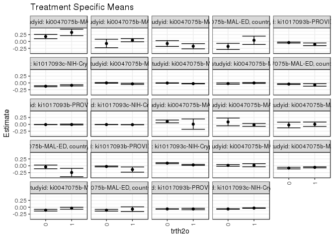

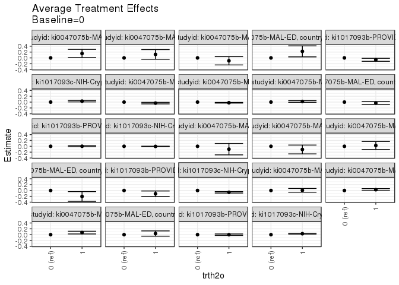

## Results Table

### Parameter: TSM

| agecat | studyid | country | intervention_level | baseline_level | estimate | ci_lower | ci_upper |
| --- | --- | --- | --- | --- | --- | --- | --- |
| 0-3 months | ki0047075b-MAL-ED | BRAZIL | 0 | NA | 0.1792561 | 0.1027959 | 0.2557163 |
| 0-3 months | ki0047075b-MAL-ED | BRAZIL | 1 | NA | 0.3304245 | 0.2129626 | 0.4478863 |
| 0-3 months | ki0047075b-MAL-ED | NEPAL | 0 | NA | -0.0734245 | -0.2286747 | 0.0818257 |
| 0-3 months | ki0047075b-MAL-ED | NEPAL | 1 | NA | 0.0470986 | -0.0103056 | 0.1045027 |
| 0-3 months | ki0047075b-MAL-ED | PERU | 0 | NA | -0.0758361 | -0.1816493 | 0.0299771 |
| 0-3 months | ki0047075b-MAL-ED | PERU | 1 | NA | -0.1741065 | -0.2690571 | -0.0791560 |
| 0-3 months | ki0047075b-MAL-ED | TANZANIA, UNITED REPUBLIC OF | 0 | NA | -0.1809516 | -0.2923482 | -0.0695550 |
| 0-3 months | ki0047075b-MAL-ED | TANZANIA, UNITED REPUBLIC OF | 1 | NA | 0.0426731 | -0.1094170 | 0.1947631 |
| 0-3 months | ki1017093b-PROVIDE | BANGLADESH | 0 | NA | -0.0405022 | -0.0588493 | -0.0221550 |
| 0-3 months | ki1017093b-PROVIDE | BANGLADESH | 1 | NA | -0.1045552 | -0.1526358 | -0.0564747 |
| 0-3 months | ki1017093c-NIH-Crypto | BANGLADESH | 0 | NA | -0.1212765 | -0.1401694 | -0.1023835 |
| 0-3 months | ki1017093c-NIH-Crypto | BANGLADESH | 1 | NA | -0.0888241 | -0.1100641 | -0.0675841 |
| 3-6 months | ki0047075b-MAL-ED | BRAZIL | 0 | NA | 0.1070668 | 0.0571647 | 0.1569690 |
| 3-6 months | ki0047075b-MAL-ED | BRAZIL | 1 | NA | 0.0084511 | -0.1798343 | 0.1967364 |
| 3-6 months | ki0047075b-MAL-ED | NEPAL | 0 | NA | 0.0882119 | -0.0530070 | 0.2294307 |
| 3-6 months | ki0047075b-MAL-ED | NEPAL | 1 | NA | -0.0205001 | -0.0733176 | 0.0323174 |
| 3-6 months | ki0047075b-MAL-ED | PERU | 0 | NA | -0.0236214 | -0.1262168 | 0.0789739 |
| 3-6 months | ki0047075b-MAL-ED | PERU | 1 | NA | 0.0036520 | -0.0765420 | 0.0838459 |
| 3-6 months | ki0047075b-MAL-ED | TANZANIA, UNITED REPUBLIC OF | 0 | NA | -0.0410643 | -0.1081175 | 0.0259890 |
| 3-6 months | ki0047075b-MAL-ED | TANZANIA, UNITED REPUBLIC OF | 1 | NA | -0.2457527 | -0.3985192 | -0.0929862 |
| 3-6 months | ki1017093b-PROVIDE | BANGLADESH | 0 | NA | -0.0246427 | -0.0412695 | -0.0080158 |
| 3-6 months | ki1017093b-PROVIDE | BANGLADESH | 1 | NA | -0.1374267 | -0.2312516 | -0.0436018 |
| 3-6 months | ki1017093c-NIH-Crypto | BANGLADESH | 0 | NA | 0.0957985 | 0.0767864 | 0.1148106 |
| 3-6 months | ki1017093c-NIH-Crypto | BANGLADESH | 1 | NA | 0.0321681 | 0.0139130 | 0.0504233 |
| 6-12 months | ki0047075b-MAL-ED | BRAZIL | 0 | NA | 0.0151480 | -0.0147880 | 0.0450839 |
| 6-12 months | ki0047075b-MAL-ED | BRAZIL | 1 | NA | 0.0204435 | -0.0361579 | 0.0770449 |
| 6-12 months | ki0047075b-MAL-ED | NEPAL | 0 | NA | -0.0841540 | -0.1141676 | -0.0541405 |
| 6-12 months | ki0047075b-MAL-ED | NEPAL | 1 | NA | -0.0570234 | -0.0765441 | -0.0375027 |
| 6-12 months | ki0047075b-MAL-ED | PERU | 0 | NA | -0.1079343 | -0.1383391 | -0.0775294 |
| 6-12 months | ki0047075b-MAL-ED | PERU | 1 | NA | -0.0368494 | -0.0723352 | -0.0013636 |
| 6-12 months | ki0047075b-MAL-ED | TANZANIA, UNITED REPUBLIC OF | 0 | NA | -0.1091758 | -0.1404418 | -0.0779099 |
| 6-12 months | ki0047075b-MAL-ED | TANZANIA, UNITED REPUBLIC OF | 1 | NA | -0.0701895 | -0.1547940 | 0.0144151 |
| 6-12 months | ki1017093b-PROVIDE | BANGLADESH | 0 | NA | -0.0629761 | -0.0700005 | -0.0559517 |
| 6-12 months | ki1017093b-PROVIDE | BANGLADESH | 1 | NA | -0.0644491 | -0.0888250 | -0.0400733 |
| 6-12 months | ki1017093c-NIH-Crypto | BANGLADESH | 0 | NA | -0.0638193 | -0.0724619 | -0.0551767 |
| 6-12 months | ki1017093c-NIH-Crypto | BANGLADESH | 1 | NA | -0.0298552 | -0.0388816 | -0.0208287 |
| 12-24 months | ki0047075b-MAL-ED | BRAZIL | 0 | NA | 0.0007187 | -0.0140945 | 0.0155319 |
| 12-24 months | ki0047075b-MAL-ED | BRAZIL | 1 | NA | -0.0340767 | -0.0557665 | -0.0123869 |
| 12-24 months | ki0047075b-MAL-ED | NEPAL | 0 | NA | -0.0041314 | -0.0122351 | 0.0039724 |
| 12-24 months | ki0047075b-MAL-ED | NEPAL | 1 | NA | -0.0263372 | -0.0346103 | -0.0180641 |
| 12-24 months | ki0047075b-MAL-ED | PERU | 0 | NA | -0.0240189 | -0.0482529 | 0.0002151 |
| 12-24 months | ki0047075b-MAL-ED | PERU | 1 | NA | -0.0017660 | -0.0186883 | 0.0151562 |
| 12-24 months | ki0047075b-MAL-ED | TANZANIA, UNITED REPUBLIC OF | 0 | NA | -0.0415527 | -0.0566565 | -0.0264488 |
| 12-24 months | ki0047075b-MAL-ED | TANZANIA, UNITED REPUBLIC OF | 1 | NA | -0.0732993 | -0.1193519 | -0.0272467 |
| 12-24 months | ki1017093b-PROVIDE | BANGLADESH | 0 | NA | -0.0082029 | -0.0121192 | -0.0042866 |
| 12-24 months | ki1017093b-PROVIDE | BANGLADESH | 1 | NA | -0.0069492 | -0.0223723 | 0.0084738 |
| 12-24 months | ki1017093c-NIH-Crypto | BANGLADESH | 0 | NA | -0.0072190 | -0.0118970 | -0.0025410 |
| 12-24 months | ki1017093c-NIH-Crypto | BANGLADESH | 1 | NA | -0.0111446 | -0.0159222 | -0.0063671 |

### Parameter: E(Y)

| agecat | studyid | country | intervention_level | baseline_level | estimate | ci_lower | ci_upper |
| --- | --- | --- | --- | --- | --- | --- | --- |
| 0-3 months | ki0047075b-MAL-ED | BRAZIL | NA | NA | 0.2008516 | 0.1322496 | 0.2694535 |
| 0-3 months | ki0047075b-MAL-ED | NEPAL | NA | NA | 0.0196732 | -0.0373357 | 0.0766822 |
| 0-3 months | ki0047075b-MAL-ED | PERU | NA | NA | -0.1548797 | -0.2348247 | -0.0749347 |
| 0-3 months | ki0047075b-MAL-ED | TANZANIA, UNITED REPUBLIC OF | NA | NA | -0.1456424 | -0.2459764 | -0.0453085 |
| 0-3 months | ki1017093b-PROVIDE | BANGLADESH | NA | NA | -0.0413143 | -0.0594662 | -0.0231624 |
| 0-3 months | ki1017093c-NIH-Crypto | BANGLADESH | NA | NA | -0.1220821 | -0.1402761 | -0.1038881 |
| 3-6 months | ki0047075b-MAL-ED | BRAZIL | NA | NA | 0.0946202 | 0.0445560 | 0.1446843 |
| 3-6 months | ki0047075b-MAL-ED | NEPAL | NA | NA | -0.0043331 | -0.0540186 | 0.0453524 |
| 3-6 months | ki0047075b-MAL-ED | PERU | NA | NA | 0.0112021 | -0.0568449 | 0.0792490 |
| 3-6 months | ki0047075b-MAL-ED | TANZANIA, UNITED REPUBLIC OF | NA | NA | -0.0703055 | -0.1355760 | -0.0050350 |
| 3-6 months | ki1017093b-PROVIDE | BANGLADESH | NA | NA | -0.0272428 | -0.0436954 | -0.0107902 |
| 3-6 months | ki1017093c-NIH-Crypto | BANGLADESH | NA | NA | 0.0267740 | 0.0099602 | 0.0435879 |
| 6-12 months | ki0047075b-MAL-ED | BRAZIL | NA | NA | 0.0158164 | -0.0114385 | 0.0430713 |
| 6-12 months | ki0047075b-MAL-ED | NEPAL | NA | NA | -0.0620266 | -0.0799254 | -0.0441279 |
| 6-12 months | ki0047075b-MAL-ED | PERU | NA | NA | -0.0517264 | -0.0824460 | -0.0210068 |
| 6-12 months | ki0047075b-MAL-ED | TANZANIA, UNITED REPUBLIC OF | NA | NA | -0.1034705 | -0.1332011 | -0.0737399 |
| 6-12 months | ki1017093b-PROVIDE | BANGLADESH | NA | NA | -0.0626151 | -0.0695574 | -0.0556729 |
| 6-12 months | ki1017093c-NIH-Crypto | BANGLADESH | NA | NA | -0.0315658 | -0.0388594 | -0.0242722 |
| 12-24 months | ki0047075b-MAL-ED | BRAZIL | NA | NA | -0.0036730 | -0.0170893 | 0.0097433 |
| 12-24 months | ki0047075b-MAL-ED | NEPAL | NA | NA | -0.0223791 | -0.0299168 | -0.0148415 |
| 12-24 months | ki0047075b-MAL-ED | PERU | NA | NA | -0.0064000 | -0.0210549 | 0.0082548 |
| 12-24 months | ki0047075b-MAL-ED | TANZANIA, UNITED REPUBLIC OF | NA | NA | -0.0460879 | -0.0610026 | -0.0311732 |
| 12-24 months | ki1017093b-PROVIDE | BANGLADESH | NA | NA | -0.0081718 | -0.0120131 | -0.0043304 |
| 12-24 months | ki1017093c-NIH-Crypto | BANGLADESH | NA | NA | -0.0057326 | -0.0097260 | -0.0017391 |

### Parameter: ATE

| agecat | studyid | country | intervention_level | baseline_level | estimate | ci_lower | ci_upper |
| --- | --- | --- | --- | --- | --- | --- | --- |
| 0-3 months | ki0047075b-MAL-ED | BRAZIL | 0 | 0 | 0.0000000 | 0.0000000 | 0.0000000 |
| 0-3 months | ki0047075b-MAL-ED | BRAZIL | 1 | 0 | 0.1511684 | 0.0110132 | 0.2913235 |
| 0-3 months | ki0047075b-MAL-ED | NEPAL | 0 | 0 | 0.0000000 | 0.0000000 | 0.0000000 |
| 0-3 months | ki0047075b-MAL-ED | NEPAL | 1 | 0 | 0.1205231 | -0.0446737 | 0.2857199 |
| 0-3 months | ki0047075b-MAL-ED | PERU | 0 | 0 | 0.0000000 | 0.0000000 | 0.0000000 |
| 0-3 months | ki0047075b-MAL-ED | PERU | 1 | 0 | -0.0982704 | -0.2404395 | 0.0438986 |
| 0-3 months | ki0047075b-MAL-ED | TANZANIA, UNITED REPUBLIC OF | 0 | 0 | 0.0000000 | 0.0000000 | 0.0000000 |
| 0-3 months | ki0047075b-MAL-ED | TANZANIA, UNITED REPUBLIC OF | 1 | 0 | 0.2236247 | 0.0351026 | 0.4121468 |
| 0-3 months | ki1017093b-PROVIDE | BANGLADESH | 0 | 0 | 0.0000000 | 0.0000000 | 0.0000000 |
| 0-3 months | ki1017093b-PROVIDE | BANGLADESH | 1 | 0 | -0.0640531 | -0.1154531 | -0.0126531 |
| 0-3 months | ki1017093c-NIH-Crypto | BANGLADESH | 0 | 0 | 0.0000000 | 0.0000000 | 0.0000000 |
| 0-3 months | ki1017093c-NIH-Crypto | BANGLADESH | 1 | 0 | 0.0324523 | 0.0063657 | 0.0585390 |
| 3-6 months | ki0047075b-MAL-ED | BRAZIL | 0 | 0 | 0.0000000 | 0.0000000 | 0.0000000 |
| 3-6 months | ki0047075b-MAL-ED | BRAZIL | 1 | 0 | -0.0986158 | -0.2934018 | 0.0961703 |
| 3-6 months | ki0047075b-MAL-ED | NEPAL | 0 | 0 | 0.0000000 | 0.0000000 | 0.0000000 |
| 3-6 months | ki0047075b-MAL-ED | NEPAL | 1 | 0 | -0.1087120 | -0.2597336 | 0.0423097 |
| 3-6 months | ki0047075b-MAL-ED | PERU | 0 | 0 | 0.0000000 | 0.0000000 | 0.0000000 |
| 3-6 months | ki0047075b-MAL-ED | PERU | 1 | 0 | 0.0272734 | -0.1115103 | 0.1660571 |
| 3-6 months | ki0047075b-MAL-ED | TANZANIA, UNITED REPUBLIC OF | 0 | 0 | 0.0000000 | 0.0000000 | 0.0000000 |
| 3-6 months | ki0047075b-MAL-ED | TANZANIA, UNITED REPUBLIC OF | 1 | 0 | -0.2046884 | -0.3715229 | -0.0378539 |
| 3-6 months | ki1017093b-PROVIDE | BANGLADESH | 0 | 0 | 0.0000000 | 0.0000000 | 0.0000000 |
| 3-6 months | ki1017093b-PROVIDE | BANGLADESH | 1 | 0 | -0.1127841 | -0.2081257 | -0.0174424 |
| 3-6 months | ki1017093c-NIH-Crypto | BANGLADESH | 0 | 0 | 0.0000000 | 0.0000000 | 0.0000000 |
| 3-6 months | ki1017093c-NIH-Crypto | BANGLADESH | 1 | 0 | -0.0636304 | -0.0881940 | -0.0390667 |
| 6-12 months | ki0047075b-MAL-ED | BRAZIL | 0 | 0 | 0.0000000 | 0.0000000 | 0.0000000 |
| 6-12 months | ki0047075b-MAL-ED | BRAZIL | 1 | 0 | 0.0052955 | -0.0581821 | 0.0687731 |
| 6-12 months | ki0047075b-MAL-ED | NEPAL | 0 | 0 | 0.0000000 | 0.0000000 | 0.0000000 |
| 6-12 months | ki0047075b-MAL-ED | NEPAL | 1 | 0 | 0.0271307 | -0.0086053 | 0.0628667 |
| 6-12 months | ki0047075b-MAL-ED | PERU | 0 | 0 | 0.0000000 | 0.0000000 | 0.0000000 |
| 6-12 months | ki0047075b-MAL-ED | PERU | 1 | 0 | 0.0710849 | 0.0249525 | 0.1172173 |
| 6-12 months | ki0047075b-MAL-ED | TANZANIA, UNITED REPUBLIC OF | 0 | 0 | 0.0000000 | 0.0000000 | 0.0000000 |
| 6-12 months | ki0047075b-MAL-ED | TANZANIA, UNITED REPUBLIC OF | 1 | 0 | 0.0389864 | -0.0512106 | 0.1291833 |
| 6-12 months | ki1017093b-PROVIDE | BANGLADESH | 0 | 0 | 0.0000000 | 0.0000000 | 0.0000000 |
| 6-12 months | ki1017093b-PROVIDE | BANGLADESH | 1 | 0 | -0.0014730 | -0.0268799 | 0.0239338 |
| 6-12 months | ki1017093c-NIH-Crypto | BANGLADESH | 0 | 0 | 0.0000000 | 0.0000000 | 0.0000000 |
| 6-12 months | ki1017093c-NIH-Crypto | BANGLADESH | 1 | 0 | 0.0339641 | 0.0213679 | 0.0465604 |
| 12-24 months | ki0047075b-MAL-ED | BRAZIL | 0 | 0 | 0.0000000 | 0.0000000 | 0.0000000 |
| 12-24 months | ki0047075b-MAL-ED | BRAZIL | 1 | 0 | -0.0347954 | -0.0610610 | -0.0085299 |
| 12-24 months | ki0047075b-MAL-ED | NEPAL | 0 | 0 | 0.0000000 | 0.0000000 | 0.0000000 |
| 12-24 months | ki0047075b-MAL-ED | NEPAL | 1 | 0 | -0.0222058 | -0.0337715 | -0.0106402 |
| 12-24 months | ki0047075b-MAL-ED | PERU | 0 | 0 | 0.0000000 | 0.0000000 | 0.0000000 |
| 12-24 months | ki0047075b-MAL-ED | PERU | 1 | 0 | 0.0222529 | -0.0069987 | 0.0515044 |
| 12-24 months | ki0047075b-MAL-ED | TANZANIA, UNITED REPUBLIC OF | 0 | 0 | 0.0000000 | 0.0000000 | 0.0000000 |
| 12-24 months | ki0047075b-MAL-ED | TANZANIA, UNITED REPUBLIC OF | 1 | 0 | -0.0317467 | -0.0802128 | 0.0167195 |
| 12-24 months | ki1017093b-PROVIDE | BANGLADESH | 0 | 0 | 0.0000000 | 0.0000000 | 0.0000000 |
| 12-24 months | ki1017093b-PROVIDE | BANGLADESH | 1 | 0 | 0.0012537 | -0.0146482 | 0.0171555 |
| 12-24 months | ki1017093c-NIH-Crypto | BANGLADESH | 0 | 0 | 0.0000000 | 0.0000000 | 0.0000000 |
| 12-24 months | ki1017093c-NIH-Crypto | BANGLADESH | 1 | 0 | -0.0039257 | -0.0105709 | 0.0027196 |